# Homework 1

Yingxin Zhang

*For all questions involving histograms, choose a sensible binwidth and breakpoints, unless otherwise indicated.*

### 1. Income

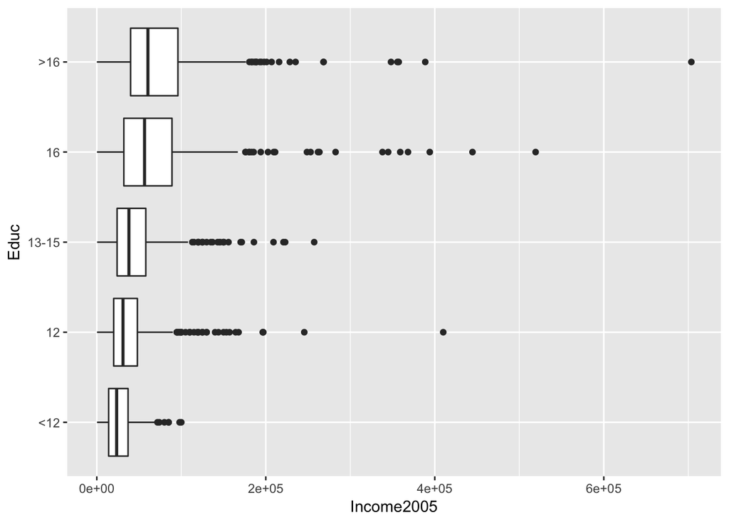

```r
#install.packages("Sleuth3")
library(Sleuth3)
library(tidyverse)

# convert Educ from an integer to a factor, and make "<12" the first factor level
mydata <- ex0525 %>%
  dplyr::mutate(Educ = forcats::fct_relevel(Educ, "<12"))
ggplot(mydata, aes(Educ, Income2005)) +
  geom_boxplot() +
  coord_flip()   # for horizontal boxplots
```

2. Plot a histogram of the `Income2005` variable in the dataset referenced in part a). [3 points]

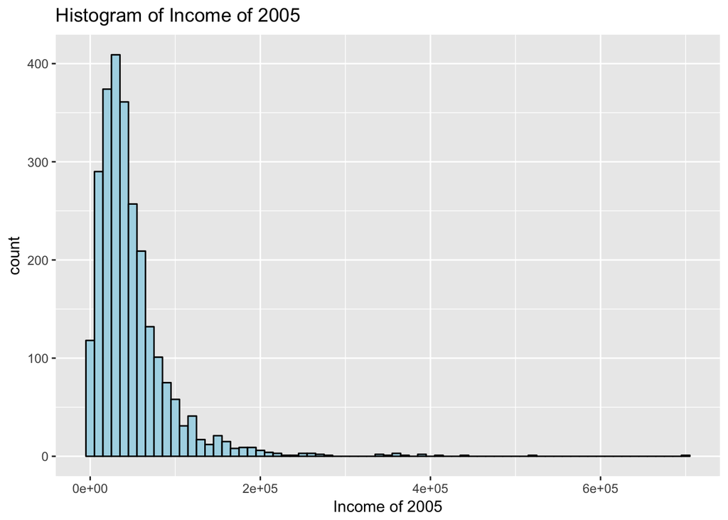

```r
library(ggplot2)
#ggplot(mydata, aes(x = Income2005)) + geom_histogram(aes(x = Income2005), binwidth = 2350) + xlim(0,705000) + xlab("Income2005") + ggtitle("Histogram of Income2005")
Income2005 = mydata$Income2005
df <- data.frame(Income2005)
ggplot(df, aes(Income2005)) + geom_histogram(color = "black", fill = "lightblue", binwidth = 10000) + xlab("Income of 2005") + ggtitle("Histogram of Income of 2005")
```

3. Use `+facet_wrap(~Educ)` to facet the histogram on education level. [3 points]

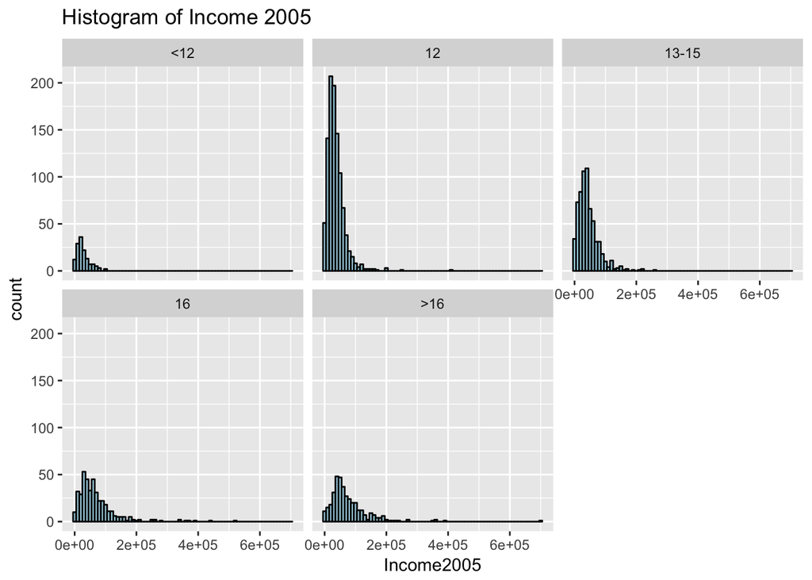

```r
ggplot(mydata, aes(x = Income2005)) + geom_histogram(color = "black", fill = "lightblue", binwidth = 10000) + xlab("Income2005") + ggtitle("Histogram of Income 2005 ") + facet_wrap(~Educ)
```

4. What do you learn from the histograms that wasn’t apparent in the boxplots from question 1? [3 points]

I can see from the histograms where the mode of the income distribution of each education level lies roughly. Histograms can also tell us the count of different income level, whereas on the boxplot, we can only see the interquatile range.

### 2. Respiratory Rates

1. Plot right closed and right open histograms for each of the two variables in the *ex0824* dataset in the **Sleuth3** package using default binwidths and breaks. (4 histograms in total). [4 points]

[figure not shown]

```r
library(Sleuth3)
library(ggplot2)
data2 = ex0824

ggplot(data2, aes(Age)) + geom_histogram(aes(x = Age), color = "black", fill = "lightblue") + xlab("Age") + ggtitle("Right Open Histogram of Age")
```

[figure not shown]

```r
ggplot(data2, aes(Age)) + geom_histogram(aes(x = Age), color = "black", fill = "lightblue", right = FALSE) + xlab("Age") + ggtitle("Right Closed Histogram of Age")
```

[figure not shown]

```r
ggplot(data2, aes(Rate)) + geom_histogram(aes(x = Rate), color = "black", fill = "lightyellow") + xlab("Rate") + ggtitle("Right Open Histogram of Rate")
```

[figure not shown]

```r
ggplot(data2, aes(Rate)) + geom_histogram(aes(x = Rate), color = "black", fill = "lightyellow", right = FALSE) + xlab("Rate") + ggtitle("Right Closed Histogram of Rate")
```

2. For which variable, `Age` or `Rate`, do the two versions differ more? Why? [3 points]

The two versions of the “Rate” variable differ more since the two “Rate” histograms clearly look different on bin heights on the two graphs. On the other hand, the two “Age” histograms almost look identical except that there might be very slight variations in the plots.

3. Redraw the `Age` histograms with different parameters so that the right closed and right open versions are identical. [3 points]

[figure not shown]

```r
ggplot(data2, aes(Age)) + geom_histogram(aes(x = Age), color = "black", fill = "lightblue", binwidth = 1.51) + xlab("Age") + ggtitle("Right Open Histogram of Age")
```

[figure not shown]

```r
ggplot(data2, aes(Age)) + geom_histogram(aes(x = Age), color = "black", fill = "lightblue", binwidth = 1.51, right = FALSE) + xlab("Age") + ggtitle("Right Closed Histogram of Age")
```

### 3. Movie budgets

Are there rounding patterns in the `budget` variable of the *movies* in the **ggplot2movies** package? If so, what are the patterns? (Note: according to the textbook this dataset is in the **ggplot2** package, but it has since been moved to a separate package.) Support your conclusions with graphical evidence. You are encouraged to break the variable down into different budget ranges and consider them separately. [8 points]

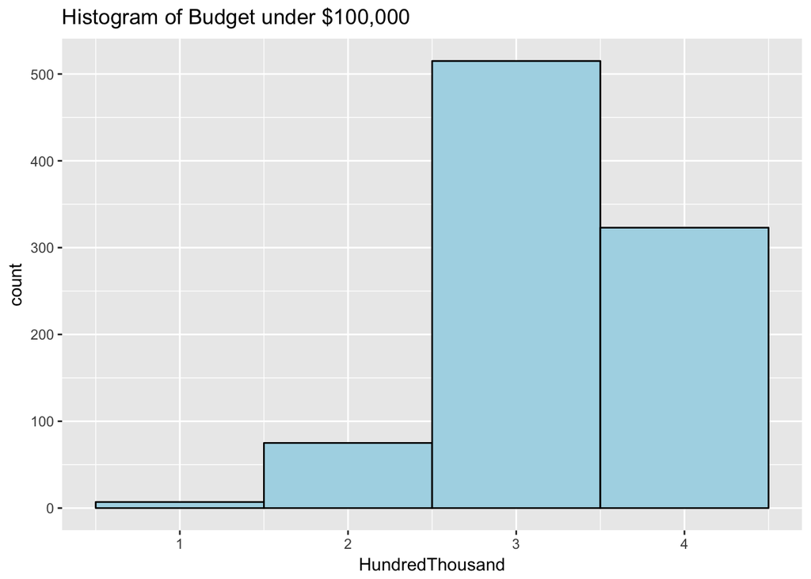

```r
library(ggplot2movies)
library(ggplot2)

data3 = movies
Budget = data3$budget
bg <- Budget[!is.na(Budget)]
sortedbg = sort(bg, decreasing = FALSE)
range1 = data.frame(sortedbg[which(sortedbg < 100000)])
range2 = data.frame(sortedbg[which((sortedbg >= 100000) & (sortedbg < 10000000))]) #10w & 1w
range3 = data.frame(sortedbg[which(sortedbg >= 10000000)]) #100w
zero1 = c(sum(range1 %% 10==0)-sum((range1 %% 100) == 0), sum((range1 %% 100) == 0)-sum((range1 %% 1000) == 0),sum((range1 %% 1000) == 0)-sum((range1 %% 10000) == 0), sum((range1 %% 10000) == 0))
# 7  75 515 323
zero2 = c(sum(range2 %% 10==0)-sum(range2 %% 100==0), sum(range2 %% 100==0)-sum(range2 %% 1000==0),sum(range2 %% 1000==0)-sum(range2 %% 10000==0), sum(range2 %% 10000==0)-sum(range2 %% 100000==0), sum(range2 %% 100000==0)-sum(range2 %% 1000000==0), sum(range2 %% 1000000==0))
# 17    8  246  354 958 873
zero3 = c(sum(range3 %% 10==0)-sum(range3 %% 100==0), sum(range3 %% 100==0)-sum(range3 %% 1000==0),sum(range3 %% 1000==0)-sum(range3 %% 10000==0), sum(range3 %% 10000==0)-sum(range3 %% 100000==0), sum(range3 %% 100000==0)-sum(range3 %% 1000000==0),sum(range3 %% 1000000==0)-sum(range3 %% 10000000==0), sum(range3 %% 10000000==0)-sum(range3 %% 100000000==0),sum(range3 %% 100000000==0))
# 0    0    0    4   59 1094  575

HundredThousand = data.frame(c(rep(1,7), rep(2,75), rep(3,515), rep(4,323)))
TenMil = data.frame(c(rep(1,17), rep(2,8), rep(3, 246), rep(4, 354), rep(5,958), rep(6,873)))
bil = data.frame(c(rep(4,4),rep(5,59),rep(6,1094), rep(7,578), rep(8, 17)))

ggplot(HundredThousand, aes(HundredThousand)) + geom_histogram(aes(x = HundredThousand), color = "black", fill = "lightblue", binwidth = 1, xlab = "Number of Zeros") + ggtitle("Histogram of Budget under $100,000")
```

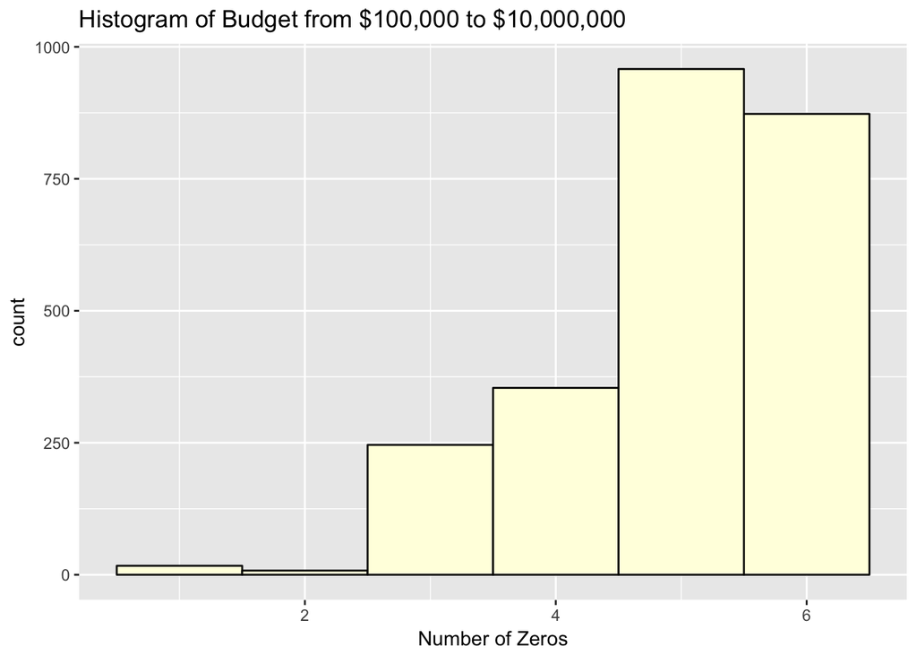

```r
ggplot(TenMil, aes(TenMil))+geom_histogram(aes(x = TenMil), color = "black", fill = "lightyellow", binwidth = 1) + xlab("Number of Zeros")+ ggtitle("Histogram of Budget from $100,000 to $10,000,000")
```

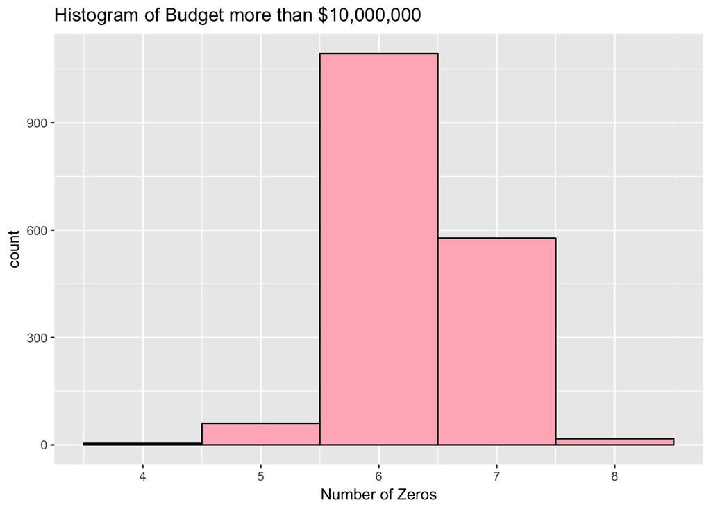

```r
ggplot(bil, aes(bil))+geom_histogram(aes(x = bil), color = "black", fill = "lightpink", binwidth = 1) + xlab("Number of Zeros") + ggtitle("Histogram of Budget more than $10,000,000")
```

### 4. Finches

1. Plot separate density histograms of the beak depth of the finches in *case0201* from the **Sleuth3** package, with density curves overlaid as on page 34 of the textbook. (However, do this by facetting on `Year` rather than using `grid.arrange`). [3 points]

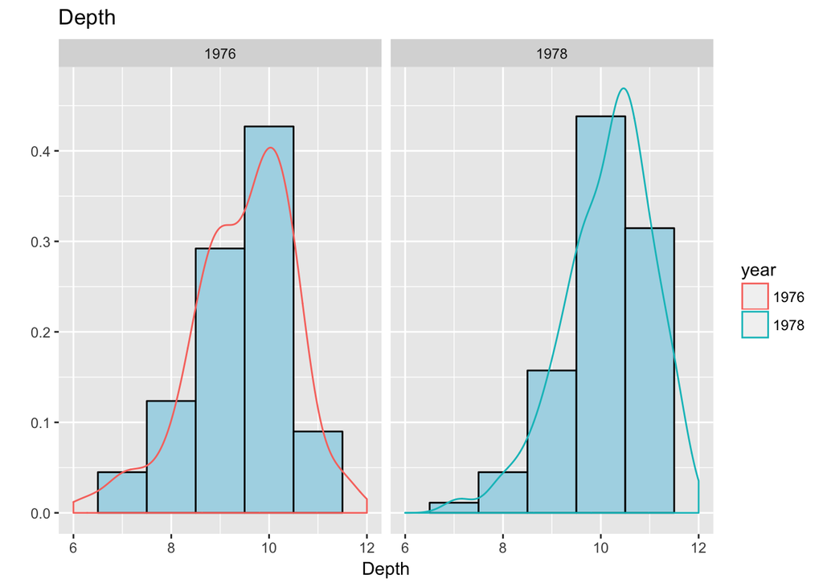

```r
library(Sleuth3)
data4 = case0201
year = as.factor(data4$Year)
ggplot(data4) +
  geom_histogram(aes(Depth, y=..density..), binwidth=1, color = "black", fill = "lightblue") +facet_wrap(~Year) +
  geom_density(aes(x = Depth, color = year)) + xlim(6, 12) + xlab("Depth") + ylab("") + ggtitle("Depth")
```

2. Plot both density curves on the same graph to facilitate comparison. Make 1976 yellow and 1978 blue. Use alpha blending so the fills are transparent. [3 points]

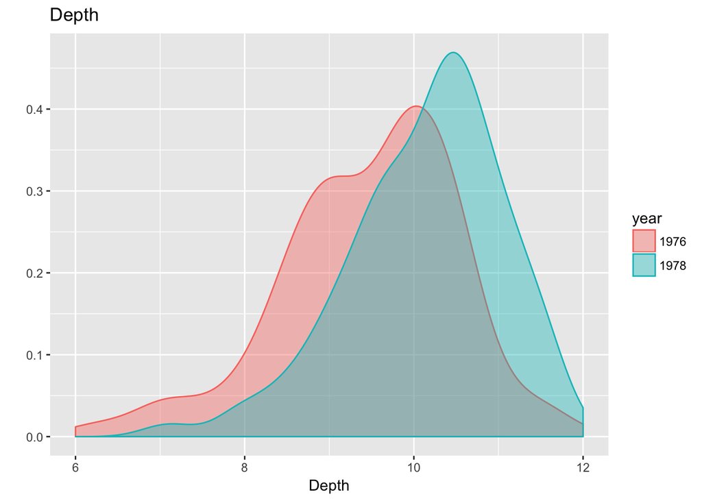

```r
ggplot(data4) +
  geom_density(aes(x = Depth, color = year, fill = year), alpha = 0.4) + xlim(6, 12) + xlab("Depth") + ylab("") + ggtitle("Depth")
```

3. Based on your graphs in parts a) and b), describe how the distributions differ by year. [3 points]

4. What is the cause of the difference according to the information in the help file? [3 points]

```r
help(case0201)
```

It is very likely that due to the drought in 1977, only birds with larger and stronger beaks could open the tough seeds and survied, thus passing the genes to their offsprings. Therefore, the birds in year 1978 had longer beak depths than the ones in year 1976.

### 5. Salary

Is the `Salary` variable in the *case0102* of **Sleuth3** normally distributed? Use two different graphical methods to provide evidence. [6 points] The Salary data are almost normally distributed. The data points in Q-Qplots are almost lying on the Q-Q line, and the histogram are looking similar to bell shape, but not exactly equal to the bell curve.

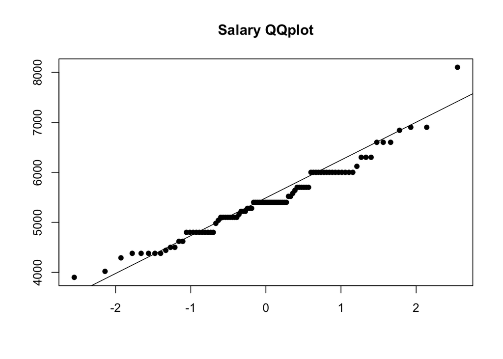

```r
library(Sleuth3)
data5 = case0102
Salary = data5$Salary
qqnorm(Salary, main="Salary QQplot", xlab="",ylab="", pch = 16)
qqline(Salary)
```

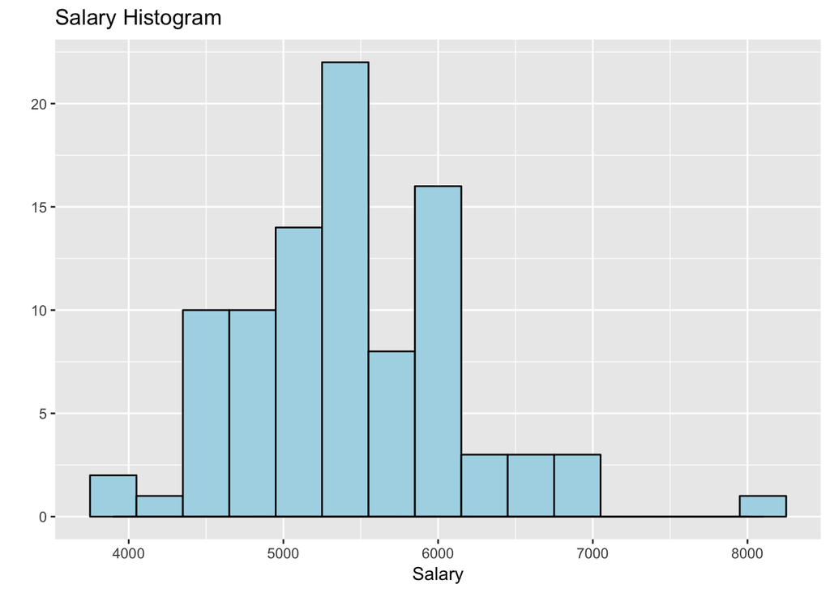

```r
library(Sleuth3)
ggplot(data5) +
  geom_histogram(aes(Salary), binwidth=300, color = "black", fill = "lightblue") +
  geom_density(aes(x = Salary))  + xlab("Salary") + ylab("") + ggtitle("Salary Histogram")
```